# soil_tutorial

## Comparison table for both models

```r
diag_table_3 <- rbind( c(round(obb_basic,3), round(acc_basic,3),                                              round(prec_basic,3),round(f1_basic,3) ),
   diag_bor <-  c(round(obb_bor,3), round(acc_bor,3),
                  round(prec_bor,3), round(f1_bor,3) ),
       diag_bor_tuned <- c(round(obb_bor_tuned,3),  round(acc_bor_tuned,3),                                      round(prec_bor_tuned,3), round(f1_bor_tuned,3) )
)
diag_table_3 <- as.data.frame(diag_table_3)
rownames(diag_table_3) <- c("Basic RF", "Boruta RF","Boruta tuned")

colnames(diag_table_3) <- c("OBB", "Accuracy", "Precision", "F1")

 best_model <- as.vector(
                 c( rownames(diag_table_3)[which.min(diag_table_3$OBB)],
                    rownames(diag_table_3 ) [which.max(diag_table_3$Accuracy)],
                    rownames(diag_table_3) [which.max(diag_table_3$Precision)],
                    rownames(diag_table_3  )[which.max(diag_table_3$F1) ]  )
                 )


 diag_table_3 <- rbind(diag_table_3, best_model)

rownames(diag_table_3) <- c("Basic RF", "Boruta RF","Boruta tuned", "Best Model")


diag_table_3
```

```
##                    OBB     Accuracy    Precision           F1
## Basic RF          0.46         0.76        0.653        0.662
## Boruta RF        0.449        0.775        0.662        0.694
## Boruta tuned     0.456         0.79        0.694        0.704
## Best Model   Boruta RF Boruta tuned Boruta tuned Boruta tuned
```

Considering only the prediction error, the tuned Boruta model performs worse than the untuned boruta model. Considering all other indicators, the tuned model performs better.

# 5.4 Probabilistic predictions

## 5.4.1

Using the optimised (or if you didn’t manage - the initial default) hyperparameters, train the Random Forest model, setting ranger::ranger(…, probability = TRUE).

This yields not a model predicting a binary class, but a probability of the target to be TRUE. This lets the user chose where to put the threshold for translating a probability to a binary class. E.g., if the predicted probability is > 0.5 , then consider this as a prediction of TRUE.

### RF_bor_prob

```r
# re-train Random Forest model
rf_bor_prob <- ranger::ranger(
  y = df_train[, target],              # target variable
  x = df_train[, predictors_selected], # Predictor variables
  seed = 42,                           # Specify the seed for randomization to reproduce the same model again
  num.threads = parallel::detectCores() - 1,
  probability = TRUE,
  min.node.size = opt_min_node_size,
  mtry = opt_mtry) # Use all but one CPU core for quick model training
```

## Generate prediction and add it to test-set - Boruta Forest

```r
# Need to load {ranger} because ranger-object is used in predict()
library(ranger)

 # Make predictions for validation sites
 prediction_bor_prob <- predict(
   rf_bor_prob,           # RF model
   data = df_test_bor,   # Predictor data
   num.threads = parallel::detectCores() - 1
   )

# Save predictions to validation df
 df_test_bor_prob <- df_test_bor
 df_test_bor_prob$pred <- prediction_bor_prob$predictions
```

## Prepare vectors for AOC Curve

```r
df_treshhold <- as.data.frame(cbind(
  "waterlog.100" = as.numeric( as.character( df_test_bor_prob$waterlog.100 ) ), "P(waterlog = 1)" =   df_test_bor_prob$pred[,2]) )

 treshholds  <-  (seq(from = 1, to = 0, -0.001) )


true_pos <- rep(NA,length(treshholds))
false_pos <- rep(NA,length(treshholds))

true_neg <- rep(NA,length(treshholds))
false_neg <- rep(NA,length(treshholds))

all_pos <- rep(70,length(treshholds))
all_neg <- rep(130, length(treshholds))
```

```r
for(i in 1:length(treshholds) ){

df_treshhold$try <- df_treshhold$`P(waterlog = 1)`

df_treshhold$try <- (df_treshhold$try >=treshholds[i])*1
# df_treshhold$try[df_treshhold$try >= treshholds[i]] <- 1
# df_treshhold$try[df_treshhold$try < treshholds[i]] <- 0


# Make classification predictions
# y_bor <- df_treshhold$waterlog.100 == 1
# x_bor <- df_treshhold$try
y_bor <- as.factor(df_treshhold$waterlog.100)
x_bor <- as.factor(df_treshhold$try*1) # Use 0.5 as threshold

# Change class names
# levels(y_bor) <- levels(x_bor) <- c("no", "yes")
y_bor <- factor(y_bor, levels = c(0,1), labels = c("no", "yes"))
x_bor <- factor(x_bor, levels = c(0,1), labels = c("no", "yes"))



as.numeric(y_bor)
as.numeric(x_bor)

# plot confusion matrix
conf_matrix_bor <- caret::confusionMatrix(data = x_bor, reference = y_bor)
conf_matrix_bor$table

# true positive rate
true_pos[i] <- conf_matrix_bor$table[2,2]
# False positive rate
false_pos[i] <- conf_matrix_bor$table[2,1]

# true negative rate
true_neg[i] <- conf_matrix_bor$table[1,1]
# False negative rate
false_neg[i] <- conf_matrix_bor$table[1,2]


}

conf_table <- as.data.frame( round(cbind(treshholds, true_neg, false_neg,true_pos, false_pos ), 3)
)
```

Then add F1 to the table

```r
conf_table <- cbind(conf_table,
                    f1 =
                      2*conf_table$true_pos/ (2*conf_table$true_pos + conf_table$false_pos + conf_table$false_neg)
)
```

### Establish the Reicever-operating-characteristic curve, as described in AGDS Book Chapter 8.3.

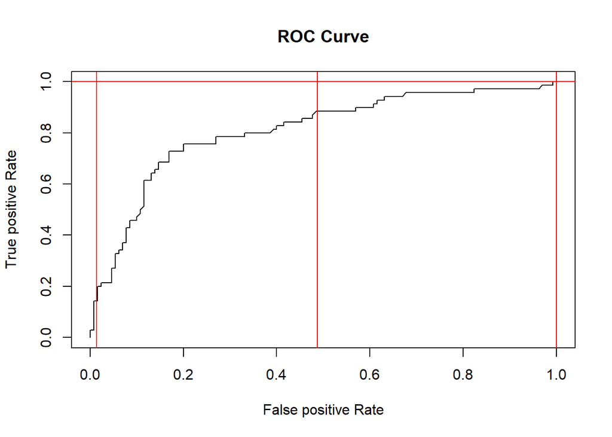

```r
true_pos_rate <- true_pos / all_pos
false_pos_rate <- false_pos / all_neg
plot(false_pos_rate, true_pos_rate, col = "black", type = "l", main = "ROC Curve", xlab = "False positive Rate", ylab = "True positive Rate", xlim = c(0,1), ylim = c(0,1) )
abline( v = 0.014, col = "red")
abline( v = 0.487, col = "red")
abline( h = 1, col = "red")
abline( v = 1, col = "red")
```

```r
# true_pos_rate
# false_pos_rate
```

## 5.4.2

Consider you inform an infrastructure construction project where waterlogged soils severely jeopardize the stability of the building. Then, consider you inform a project where waterlogged soils are unwanted, but not critical. In both cases, your prediction map of a binary classification is used as a basis and the binary classification is derived from the probabilistic prediction.

### How would you chose the threshold in each case?

For the first case, I would chose the highest treshhold where I still don’t have any false negatives.

```r
max_treshold_0_FN <- max(conf_table$treshholds[conf_table$false_neg == 0])


cat ("The highest treshhold without any false negatives would be ", max_treshold_0_FN)
```

```
## The highest treshhold without any false negatives would be  0.014
```

This said, this is an extremely conservative choice. Alternatively, the treshhold could be chosen, after which increases in FP-rate are consistenly greater than the ones in the TP- Rate, which would be somewhere around 0.2

For the second case, I would chose a treshhold, which maximises an overall metric, e.g. the F1.

```r
max_treshold_F1 <- conf_table$treshholds[which.max(conf_table$f1)]

cat ("The the treshhold returning the highest F1 would be ", max_treshold_F1, "with a a corresponding F1 of ",round(max(conf_table$f1),3) )
```

```
## The the treshhold returning the highest F1 would be  0.487 with a a corresponding F1 of  0.713
```

### Would you chose the same threshold in both cases? If not, explain why.

Answer:

I would not chose the same treshhold in both cases because in the first example, false negatives are to be avoided as much as possible. This implies that there will be more buildings that we declare to be “unsave” even though they would be save (more false positives)

In the second example on the other hand, they are not that critical and we can try to strike a balance in minimizing both, false positivs and false negatives.

### Can you think of an analogy of a similarly-natured problem in another realm?

Answer :

An analogy would be the testing of new drugs:

While testing a new drug for a serious disease, e.g. cancer, we want to minimize Type I Errors, while Type II Errors are not very crucial. I.e. we only want to measure the effect of the drug given it exists (minimize false positives) and we accept,rejecting the use of the drug in some cases, event though it could help (we have more false negatives in return)

The other case would be the assesment of side effects of a new drug.

In that case we want to minimize false negatives, meaning we don’t want any cases were we don’t claim there are serious side-effect, even though they exist. At the same time we still don’t want many false positives, meaning cases were we predict side effects to occur, even though that won’t be the case. So, very similar to the infrastructure example, we would try to strike an overall balance between the two.

References:

Schratz, P., Muenchow, J., Iturritxa, E., Richter, J., & Brenning, A. (2019). Hyperparameter tuning and performance assessment of statistical and machine-learning algorithms using spatial data. Ecological Modelling, 406, 109–120.